# Linear Predictions between COVID Cases and COVID Deaths

## “I like California in June”

The Offset 9 prediction intercepts the actual data around the 5000 death mark, which is in the middle of June. Subsequently the data deviates significantly from the model. This requires building a data frame with just the June data and running a correlation test to validate the offset.

```r
cor(june_offset_df[2:length(colnames(june_offset_df))])[2,]
```

```
## daily_total_confirmed    daily_total_deaths              offset_1
##             0.9814765             1.0000000             0.9815363
##              offset_2              offset_3              offset_4
##             0.9817678             0.9830717             0.9851963
##              offset_5              offset_6              offset_7
##             0.9875528             0.9893667             0.9907568
##              offset_8              offset_9             offset_10
##             0.9921750             0.9933800             0.9948098
##             offset_11             offset_12             offset_13
##             0.9963907             0.9972745             0.9976784
##             offset_14             offset_15             offset_16
##             0.9978578             0.9975115             0.9972116
##             offset_17             offset_18             offset_19
##             0.9971950             0.9972744             0.9971628
##             offset_20             offset_21
##             0.9970676             0.9967216
```

```
## [1] "June Offset 13 residuals: 53640.3928940913"
```

```
## [1] "June Offset 14 residuals: 49500.5512911547"
```

```
## [1] "June Offset 15 residuals: 57490.9794889714"
```

```
## [1] "June offset 14 is less than offset 13? TRUE"
```

```
## [1] "June offset 14 is less than offset 15? TRUE"
```

Offset 14 has the smallest residual which corresposnds with the highest correlation value in the offset table. This is further supported by calculating the residuals of offset 13 and 15 which were both higher. Since we are using a linear model offset 14 appears to be the best choice.

Here’s the plot of June confirmed and deaths. The red line is the prediction.

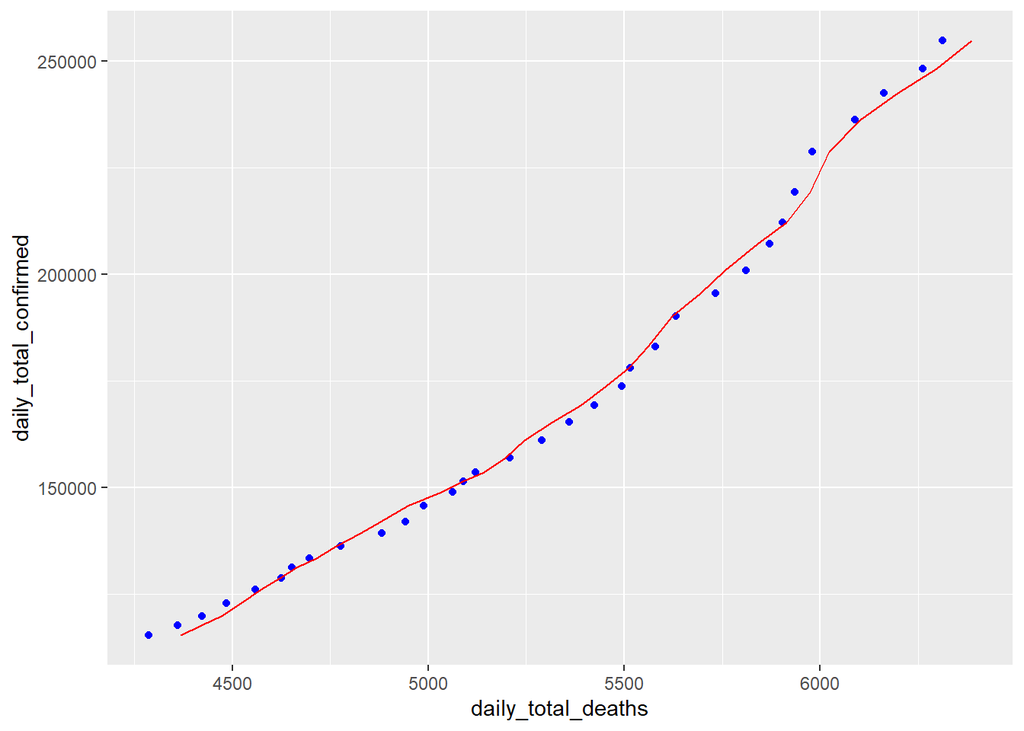

That result stopped me in my tracks. There appears to be a very tight correlation between predicted deaths and the reported confirmed cases from 14 days prior. The data also demonstrates the offset days shifted during the pandemic. Likely due to an increase in testing and people not waiting as long to get tested. This is an interesting find and I intend to keep picking at it.

[^1]: The official numbers from the State are available at:https://data.ca.gov/group/covid-19
[^2]: People are generally tested when displaying symptoms. Although some tests are performed post mortem.
[^3]: I could not find the original article where I sourced that information. Right or wrong it’s a place to start